# Séance 3 : Analyse de réseaux avec R

## Analyser les places

Examinons la distribution des étudiants dans les places :

```r
table(places_df$NbElements)
```

```
##
##   1   2   3   4   5   7  10  11  12  15  16  18
## 179  15  12   4   1   3   1   1   1   2   2   2
```

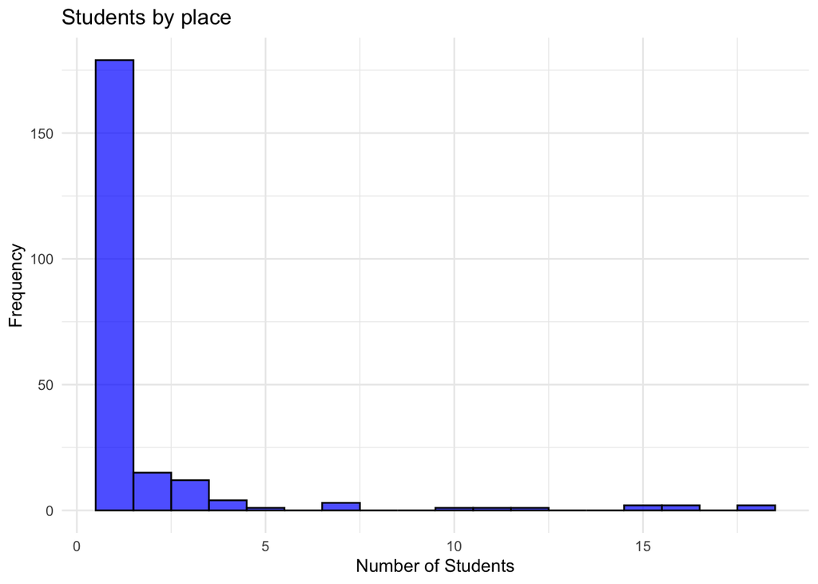

```r
library(ggplot2)

ggplot(places_df, aes(x = NbElements)) +
  geom_histogram(binwidth = 1, fill = "blue", color = "black", alpha = 0.7) +
  labs(title = "Students by place",
       x = "Number of Students",
       y = "Frequency") +
  theme_minimal()
```

Examinons la distribution des universités dans les places :

```r
table(places_df$NbSets)
```

```
##
##   1   2   3   4
##  79 119  21   4
```

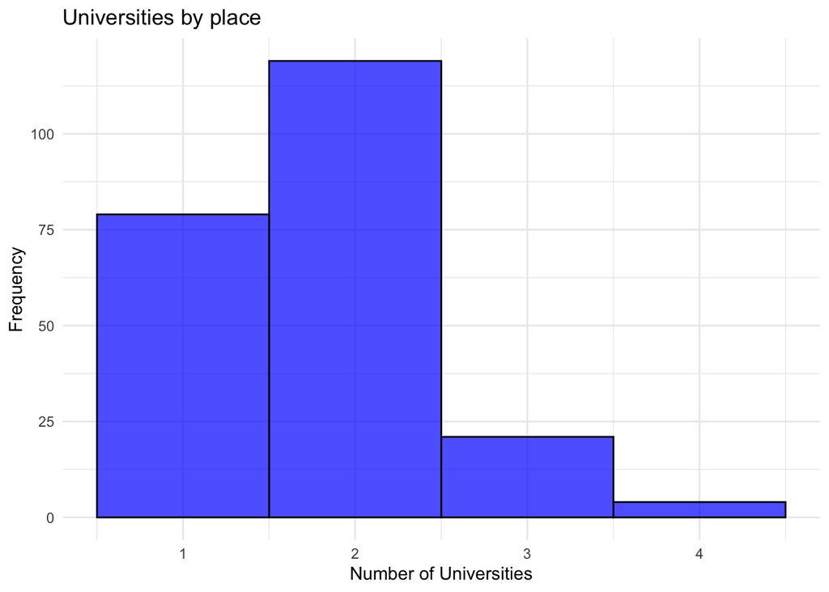

```r
ggplot(places_df, aes(x = NbSets)) +
  geom_histogram(binwidth = 1, fill = "blue", color = "black", alpha = 0.7) +
  labs(title = "Universities by place",
       x = "Number of Universities",
       y = "Frequency") +
  theme_minimal()
```

Extrayons les places plus significatives :

```r
kable(places_df %>% filter(NbElements >1 & NbSets>1)) %>%
  kable_styling(full_width = FALSE, bootstrap_options = c("striped", "hover"))
```

| PlaceNumber | PlaceLabel | NbElements | NbSets | PlaceDetail |
| --- | --- | --- | --- | --- |
| 26 | P026(4-2) | 4 | 2 | {Chu_Percy;Lee_Alfred S.;Liang_Louis K.L.;Sun_J.H.} - {Columbia;New York University} |
| 27 | P027(3-2) | 3 | 2 | {Au_Silwing P.C.;Yee_S.K.;Zee_Andrew} - {Chicago;Michigan} |
| 28 | P028(3-2) | 3 | 2 | {Chang_Ting-Chin;Hsueh_Wei Fan;Wong_Tse-Kong} - {Ohio State;Pennsylvania} |
| 29 | P029(3-2) | 3 | 2 | {Ho_Teh-Kuei;Sze_F.C.;Tsai_Thomas Wen-hsi} - {Harvard;Wisconsin} |
| 30 | P030(3-2) | 3 | 2 | {Huang_H.L.;Wang_K.P.;Welles_Henry H.} - {Columbia;Princeton} |
| 31 | P031(2-2) | 2 | 2 | {Chen_Kwan-Pu;Wong_I.K.} - {Pennsylvania;St. John’s University} |
| 32 | P032(2-2) | 2 | 2 | {Jen_Lemuel C.C.;West_Eric Ralph} - {California;George Washington} |
| 33 | P033(2-2) | 2 | 2 | {Lee_Shee-Mou;Parker_Frederick A.} - {Harvard;Massachusetts Institute of Technology} |
| 34 | P034(2-2) | 2 | 2 | {Lin_Peter Wei;Ma_Y.C.} - {Columbia;Yale} |
| 35 | P035(2-2) | 2 | 2 | {Lum_Joe W.;Wu_Jack Foy} - {Columbia;Stanford} |
| 36 | P036(2-2) | 2 | 2 | {Ngao_Sz-Chow;Speery_Henry M.} - {Columbia;Michigan} |
| 37 | P037(2-2) | 2 | 2 | {Sze_Ying Tse-yu;Zhen_M.S.} - {Columbia;Massachusetts Institute of Technology} |
| 38 | P038(2-2) | 2 | 2 | {Tsao_Y.S.;Yen_Fu-ching} - {Harvard;Yale} |

Extraire les informations à l’intérieur des places (utile si l’on a besoin d’associer les étudiants ou les universités à la place qui leur correspond) :

```r
places_data <- as.data.frame(places$data)
```

```r
  places_data %>%
  head(5) %>%
  kable() %>%
  kable_styling(full_width = FALSE, bootstrap_options = c("striped", "hover"))
```

|  | Elem | Set | Places |
| --- | --- | --- | --- |
| 51 | Lacy_Carleton | Columbia | P001(1-4) |
| 48 | Lacy_Carleton | Garrett Biblical Institute | P001(1-4) |
| 49 | Lacy_Carleton | Northwestern | P001(1-4) |
| 52 | Lacy_Carleton | Ohio Wesleyan | P001(1-4) |
| 592 | Luccock_Emory W. | McCormick Seminary | P002(1-4) |

## Projections

Nous allons maintenant extraire les deux réseaux complémentaires issus de la recherche d’équivalence dans notre réseau bipartite de départ :

- Le réseau de places (étudiants structurellement équivalents) liées par les universités :
- Le réseau d’universités liés par les places.

```r
Net <- graph_from_data_frame(places$Edgelist, directed = FALSE)

## transformation en réseau bipartite

V(Net)$type <- bipartite_mapping(Net)$type

# Projection

projNet <- bipartite_projection(Net, multiplicity = TRUE)
Net1 <- projNet$proj1  # Réseau d'éléments/places (étudiants structurellement équivalents)
Net2 <- projNet$proj2  # Réseau de sets (universités)
```

**A retenir**

1. Le réseau bipartite construit à partir des places est une réduction de notre réseau bipartite de départ. Les noeuds ne correspondent plus à un étudiant isolé, mais à un groupe d’étudiants structurellement équivalents.
2. Certaines places ne contiennent qu’un seul étudiant, ce qui signifie que cet étudiant occupe une position unique dans le réseau. Il est lié à une combinaison unique d’universités, et aucun autre étudiant ne présente la même combinaison.
3. Par rapport aux projections classiques construites directement à partir du réseau bipartite de départ, la projection à partir des places présente l’avantage d’éliminer les redondances et de conserver la quintessence du réseau, sans perdre d’informations.

Projetons le graphe des places liés par les universités :

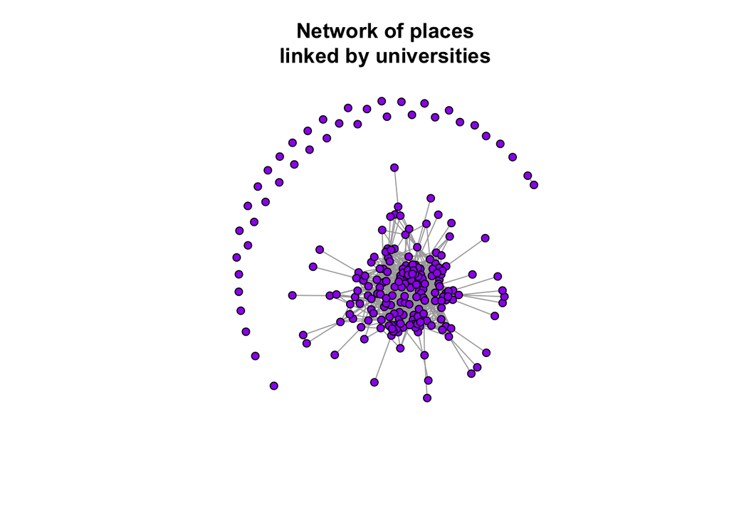

```r
plot(Net1, vertex.size = 5,
     vertex.color = "purple",
     vertex.label = NA,
     main="Network of places\nlinked by universities")
```

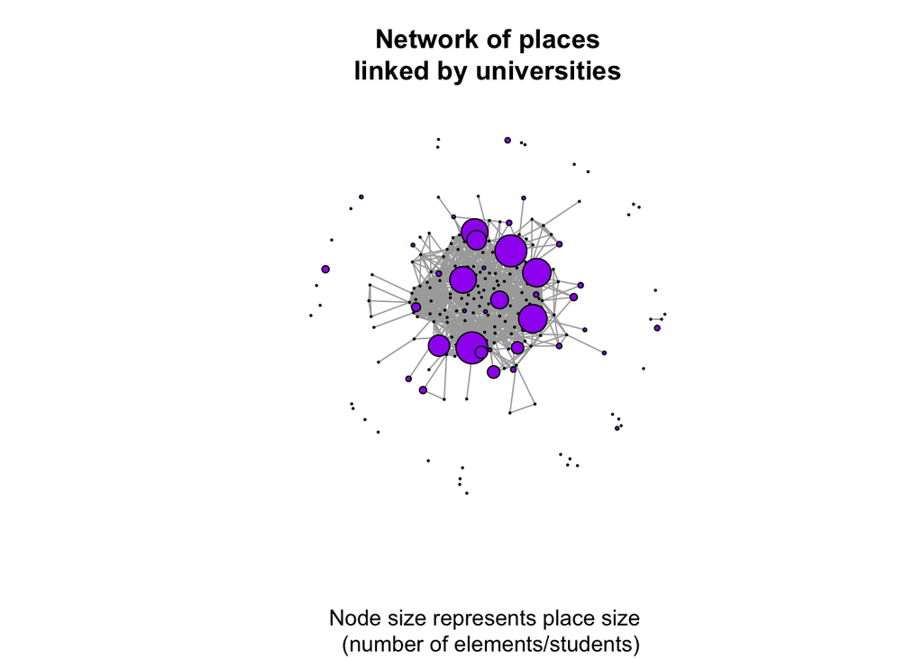

```r
# Ajuster la taille des noeuds en fonction du nombre d'étudiants dans chaque place :

V(Net1)$size <- places_df$NbElements

plot(Net1, vertex.size = V(Net1)$size,
     vertex.color = "purple",
     vertex.label = NA,
     layout = layout_components,
     main="Network of places\nlinked by universities",
     sub = "Node size represents place size \n (number of elements/students)")
```

Projetons maintenant le graphe des universités liées par les places :

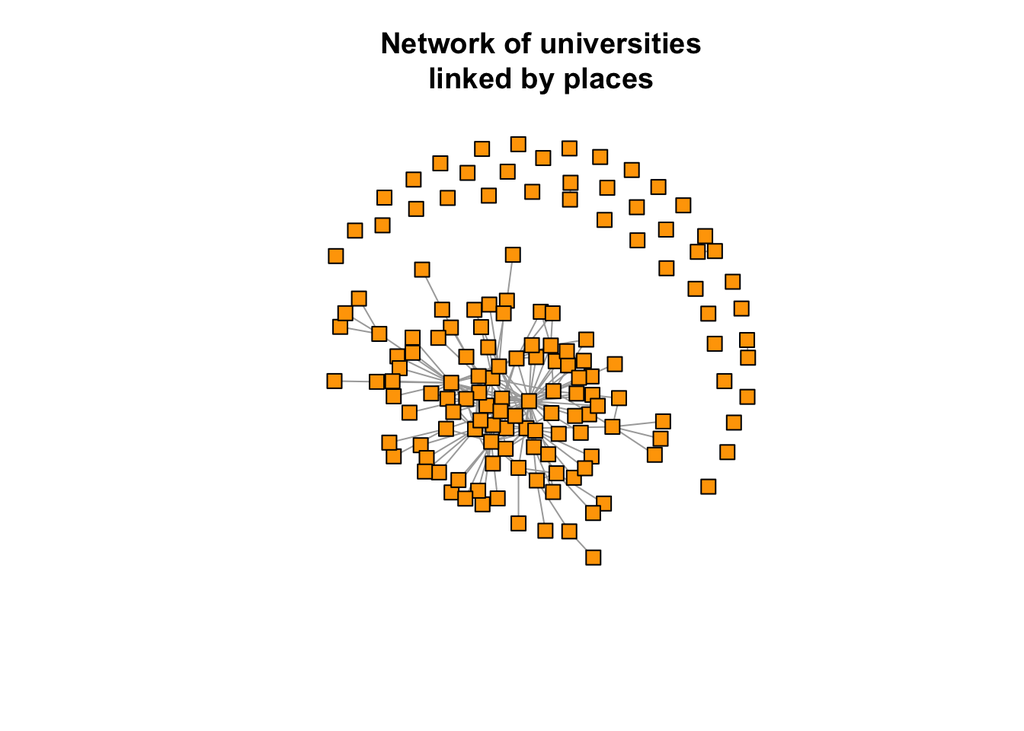

```r
plot(Net2, vertex.size = 7,
     vertex.color = "orange",
     vertex.label = NA,
     vertex.shape = "square",
     main="Network of universities\nlinked by places")
```

## Poids des liens

Comme les deux réseaux sont valués, il est intéressant d’analyser le poids des liens :

```r
table(E(Net1)$weight)
```

```
##
##    1    2
## 1589   12
```

```r
table(E(Net2)$weight)
```

```
##
##   1   2   4
## 190   6   1
```

Examinons de plus près les paires de places et d’universités qui ont les liens les plus forts, qui représentent les parcours d’étudiants les plus fréquents ou typiques

```r
E(Net1)[weight > 1]
```

```
## + 12/1601 edges from 485b612 (vertex names):
##  [1] P003(1-4)--P016(1-3) P003(1-4)--P018(1-3) P003(1-4)--P026(4-2)
##  [4] P003(1-4)--P121(1-2) P007(1-3)--P019(1-3) P007(1-3)--P085(1-2)
##  [7] P015(1-3)--P031(2-2) P015(1-3)--P052(1-2) P016(1-3)--P018(1-3)
## [10] P016(1-3)--P026(4-2) P017(1-3)--P072(1-2) P018(1-3)--P026(4-2)
```

```r
E(Net2)[weight == 2]
```

```
## + 6/197 edges from 55db763 (vertex names):
## [1] Columbia           --California
## [2] Columbia           --Pomona
## [3] Columbia           --Chicago
## [4] New York University--Pennsylvania
## [5] Pennsylvania       --Hawaii
## [6] Pennsylvania       --St. John's University
```

```r
E(Net2)[weight == 4]
```

```
## + 1/197 edge from 55db763 (vertex names):
## [1] Columbia--New York University
```

## Mesures et communuautés

On peut appliquer en toute sécurité les mesures classiques conçues pour les réseaux simples (voir section 1).

De même, on peut appliquer la détection de communautés sans risque de créer des clusters artificiels, puisque les liens redondants ont été fusionnés grâce aux places (voir section 1).

**Note** Comme les réseaux ne sont pas connexes (ils contiennent plusieurs composantes non connectées), il est préférable d’extraire la composante principale pour le calcul les mesures d’intermédiarité et de proximité, ainsi que pour la détection de communuautés. Pour extraire la composante principale, on peut appliquer le code suivant :

```r
# Identifier les composantes connectées
compo1 <- components(Net1)
compo2 <- components(Net2)

# Extraire les sommets de la plus grande composante
giant_compo1 <- which(compo1$membership == which.max(compo1$csize))
giant_compo2 <- which(compo2$membership == which.max(compo2$csize))

# Extraire la composante principale comme un sous-graphe
main_compo1 <- induced_subgraph(Net1, giant_compo1)
main_compo2 <- induced_subgraph(Net1, giant_compo2)
```

## Equivalences régulières (*k-place*)

La fonction **kplace()** permet d’extraire les équivalences régulières. Sa structure est similaire à la fonction de place(), mais elle contient en plus un argument spécifique pour spécifier le nombre de différences tolérées dans la recherche d’équivalence. Par exemple, si k = 1, on tolère que les étudiants diffèrent par une université, si k = 2, qu’ils aient deux universités différentes, etc :

```r
kplaces <- kplaces(data = auc_edge, col.elements = "Student", col.sets = "University", k = 1)
kplaces <- kplaces(auc_edge, "Student", "University", 1) # version abrégée
```

La fonction **k-places()** retourne une liste composée de quatre dataframes :

- Le dataframe d’origine avec en plus une colonne « Places » contenant les places détectées.
- Un dataframe contenant des informations sur les places et les k-places.
- Un dataframe présentant les relations entre les places fusionnées avec les k-places et les ensembles communs.
- Le réseau des places sous la forme d’une liste d’arêtes en deux modes.

Le dataframe, contenant des informations sur les places et les k-places renseigne les caractéristiques suivantes :

- PlaceLabel contient les étiquettes des places et des k-places. Les étiquettes des places commencent par « P », suivie du numéro de place, du nombre d’éléments dans la place et du nombre d’ensembles définissant la place. Les étiquettes des k-places commencent aussi par « P », suivies du numéro de k-place, d’un *, du nombre d’éléments dans la k-place, du nombre d’ensembles communs et de la valeur de k.
- NbElements contient le nombre d’éléments dans la place ou la k-place.
- NbSets contient le nombre d’ensembles définissant la place ou la k-place.
- PlaceDetail contient le nom de tous les éléments présents dans la place ou la k-place, ainsi que tous les ensembles définissant cette place ou k-place.

Extrayons les places et kplaces détectées :

```r
places2_df <- as.data.frame(kplaces$KPlacesData) # toutes les équivalences
kplaces_df <- as.data.frame(kplaces$kPlaces) # équivalences régulières uniquement
```

```r
  places2_df %>%
  head(5) %>%
  kable() %>%
  kable_styling(full_width = FALSE, bootstrap_options = c("striped", "hover"))
```

| PlaceLabel | NbElements | NbSets | PlaceDetail |
| --- | --- | --- | --- |
| P001(1-4) | 1 | 4 | {Lacy_Carleton} - {Columbia;Garrett Biblical Institute;Northwestern;Ohio Wesleyan} |
| P002(1-4) | 1 | 4 | {Luccock_Emory W.} - {McCormick Seminary;Northwestern;Wabash;Wooster} |
| P003(1-4) | 1 | 4 | {Ly_J .Usang} - {Columbia;Haverford;New York University;Pennsylvania} |
| P004(1-4) | 1 | 4 | {Pott_Francis L. Hawks} - {Columbia;General Theological Seminary;Trinity;University of Edinburgh} |
| P005(1-3) | 1 | 3 | {Chu_Fred M.C.} - {Chicago;Pratt Institute;Y.M.C.A. College} |

```r
  kplaces_df %>%
  head(5) %>%
  kable() %>%
  kable_styling(full_width = FALSE, bootstrap_options = c("striped", "hover"))
```

|  | k_places | Places | Common_Sets |
| --- | --- | --- | --- |
| 380 | P007*(2-3-2-1) | P007(1-3) | Columbia,Pomona |
| 384 | P007*(2-3-2-1) | P085(1-2) | Columbia,Pomona |
| 45 | P017*(2-3-2-1) | P017(1-3) | Chicago,Columbia |
| 87 | P017*(2-3-2-1) | P072(1-2) | Chicago,Columbia |

## Quizz

1. Observez la distribution des étudiants et des universités dans les places. Comment peut-on l’interpréter ?
2. Quelle place contient le plus grand nombre d’étudiants ? Quelle place contient le plus grand nombre d’universités ? Quelle est la place qui contient à la fois le plus grand nombre d’étudiants et d’universités ?
3. Identifier les liens forts dans les deux réseaux complémentaires de places et d’universités. A quoi correspondent-ils ? Comment les interpréter ?

**Important à retenir**

- La notion de **places** peut prêter à confusion. Elle ne doit pas être entendue au sens géographique, mais comme un synonyme de la notion d’équivalence, i.e. au sens de position dans un réseau.
- De même, Le package *Places* (avec une majuscule) dédié à la recherche d’équivalence dans un réseau - ne doit pas être confondu avec le package **places** (minuscule) (un ancien package dédié à l’analyse géographique).

**Note** : D’autres outils existent pour la recherche d’équivalences notamment le package **blockmodeling** ou les fonctions **equiv.clust()* et** blockmodel()** du package **sna**. Le package **Places** offre une solution robuste particulièrement adaptée à l’analyse des réseaux bipartites et relativement bien documentée (voir notamment la fiche [RZine](https://rzine.fr/bibliography/article_8/) dédiée).

# Bonus : R vers Cytoscape et Gephi

**igraph** est un très bon package pour l’analyse et la manipulation des données (conversion entre formats, calculs de centralités, détection de communautés), mais il est moins efficace pour la visualisation. Il est souvent utile d’utiliser en complément un logiciel de visualisation de réseau comme [Gephi](https://gephi.org/) ou [Cytoscape](https://cytoscape.org/) qui permettent d’explorer et d’interagir avec le réseau.

Deux options s’offrent à vous :

- construire vos réseaux directement dans les logiciels spécialisés et les explorer en parallèle de R ;
- faire communiquer directement R avec les logiciels en utilisant les packages spécifiques [RCy3](https://cytoscape.org/RCy3/articles/Overview-of-RCy3.html) ou [Cyrface](https://saezlab.github.io/cyrface/) et [GephiForR](https://cran.r-project.org/web/packages/GephiForR/refman/GephiForR.html).

# Remarques finales

L’une des principales difficultés de l’analyse de réseau est de parvenir à transposer ses concepts à nos données particulières et de savoir interpréter les résultats dans le contexte de notre recherche. Certaines mesures et certains outils de l’analyse de réseaux sont plus ou moins pertinents selon les cas. Il est important de se demander, par exemple, à quoi correspond un fort degré de centralité ou d’intermédiarité dans le cas précis étudié (e.g., d’un mot dans un réseau sémantique) ? De même, à quoi correspond une communauté de mots ? Quelles interprétations peut-on en tirer ?

# Références

Voici une sélection de références essentielles pour l’analyse de réseaux avec R, adaptées aux doctorants en SHS :

## Ouvrages de référence généraux

1. Borgatti, Everett, Johnson & Agneessens. *Analyzing Social Networks* (3e éd., 2024). Sage Publications. Manuel clair et structuré (mesures, collecte, éthique, études de cas)
2. Scott, J. (2017). *Social Network Analysis* (4e édition). Sage Publications. Introduction accessible aux concepts clés, particulièrement adaptée aux sciences sociales, avec une approche progressive.
3. Wasserman, S., & Faust, K. (1994). *Social Network Analysis: Methods and Applications*. Cambridge University Press. Le manuel de référence incontournable, couvrant exhaustivement les fondements théoriques et méthodologiques de l’analyse de réseaux sociaux.

## Manuels spécifiques à R

4. Luke, D. A. (2015). *A User’s Guide to Network Analysis in R*. Springer. Guide pratique et accessible, spécifiquement conçu pour les utilisateurs de R en sciences sociales, avec de nombreux exemples concrets.
5. Ognyanova, K. (2021). *Network Analysis and Visualization with R and igraph*. Tutoriel en ligne exhaustif et régulièrement mis à jour, disponible gratuitement : https://kateto.net/netscix2016.html
6. Kolaczyk, E. D., & Csárdi, G. (2014). *Statistical Analysis of Network Data with R*. Springer. Approche plus statistique et avancée, excellent pour les aspects méthodologiques rigoureux.

## Ressources pratiques et tutoriels

7. Beauguitte, L. (2016). “Analyser les réseaux sociaux avec R”. *Groupe FMR*. Ressource en français spécifiquement dédiée à R, avec une approche pédagogique adaptée aux SHS.
8. Briatte, F. (2016). “Network Analysis and Political Science”. *PS: Political Science & Politics*, 49(2), 245-250. Article méthodologique centré sur les applications en science politique, avec code R disponible.
9. Grandjean, M. (2015). *Introduction à la visualisation de données : l’analyse de réseau en histoire*. Geschichte und Informatik, 18/19, 109-128. Approche historique de l’analyse de réseaux avec des exemples pratiques en R.

Ces références couvrent le spectre complet depuis les fondements théoriques jusqu’à l’implémentation pratique en R, avec plusieurs ressources en français pour faciliter l’appropriation des concepts. Je recommande de commencer par Scott (2017) pour les concepts, puis Luke (2015) pour la pratique avec R, en complément du tutoriel d’Ognyanova pour la visualisation.